# The Phillips Curve

May 2023

# Introduction

This is an exercise to analyse the performance of the Phillips Curve. The task is to download data from the IMF World Economic Outlook Database. You can find that here:

[World Economic Outlook Database](https://www.imf.org/en/Publications/SPROLLs/world-economic-outlook-databases)

You must download the data and save it was a csv file. This is a difficult file to manage because it is actually a `tab-separated-variable` file and because the data is presented in rows rather than the usual columns. Managing and sorting out data is a key part of this exercise. It is not unusual to find that this takes more time than the analysis.

## Read the data into R

If you have set up a `Project` and have the data file in the same directory or folder as your R code, you will not need `../../` before the name in your data file. You may not need `fileEncoding = 'UTF-16LE'` or `blank.lines.skip = TRUE`. Try it with and without. If in doubt, please post a question to the discussion board.

```r
da <- read.delim('../../Data/WEO_Data.csv', fileEncoding = 'UTF-16LE',
                 blank.lines.skip = TRUE)
str(da)
```

```
## 'data.frame':    4 obs. of  49 variables:
##  $ Country                      : Factor w/ 3 levels "","International Monetary Fund, World Economic Outlook Database, April 2023",..: 3 3 1 2
##  $ Subject.Descriptor           : Factor w/ 3 levels "","Inflation, average consumer prices",..: 2 3 1 1
##  $ Units                        : Factor w/ 3 levels "","Percent change",..: 2 3 1 1
##  $ Scale                        : logi  NA NA NA NA
##  $ Country.Series.specific.Notes: Factor w/ 3 levels "","See notes for:  Inflation, average consumer prices (Index).",..: 2 3 1 1
##  $ X1980                        : num  13.5 7.17 NA NA
##  $ X1981                        : num  10.38 7.62 NA NA
##  $ X1982                        : num  6.16 9.71 NA NA
##  $ X1983                        : num  3.16 9.6 NA NA
##  $ X1984                        : num  4.37 7.51 NA NA
##  $ X1985                        : num  3.53 7.19 NA NA
##  $ X1986                        : num  1.94 7 NA NA
##  $ X1987                        : num  3.58 6.17 NA NA
##  $ X1988                        : num  4.1 5.49 NA NA
```

[output cut: 35 more lines]

```r
head(da)
```

```
##                                                                    Country
## 1                                                            United States
## 2                                                            United States
## 3
## 4 International Monetary Fund, World Economic Outlook Database, April 2023
##                   Subject.Descriptor                        Units Scale
## 1 Inflation, average consumer prices               Percent change    NA
## 2                  Unemployment rate Percent of total labor force    NA
## 3                                                                    NA
## 4                                                                    NA
##                                                                                                                                      Country.Series.specific.Notes
## 1                                                                                                      See notes for:  Inflation, average consumer prices (Index).
## 2 Source: National Statistics Office Latest actual data: 2022 Employment type: National definition Primary domestic currency: US dollar Data last updated: 03/2023
## 3
## 4
```

[output cut: 20 more lines]

**THIS IS A MESS**

## Create a data frame

We create a dataframe from this mess and check the results. Make sure that you understand all the steps.

```r
head(t(da[1:2,7:length(da)-1]))
```

```
##            1     2
## X1980 13.502 7.175
## X1981 10.378 7.617
## X1982  6.158 9.708
## X1983  3.160 9.600
## X1984  4.368 7.508
## X1985  3.528 7.192
```

```r
tail(t(da[1:2,7:length(da)-1]))
```

```
##           1     2
## X2017 2.131 4.358
## X2018 2.439 3.892
## X2019 1.813 3.683
## X2020 1.251 8.092
## X2021 4.683 5.367
## X2022 7.986 3.642
```

```r
str(t(da[1:2,7:length(da)-1]))
```

```
##  num [1:43, 1:2] 13.5 10.38 6.16 3.16 4.37 ...
##  - attr(*, "dimnames")=List of 2
##   ..$ : chr [1:43] "X1980" "X1981" "X1982" "X1983" ...
##   ..$ : chr [1:2] "1" "2"
```

```r
Unemployment = t(unname(da[2, c(7:length(da)-1)]))
head(Unemployment)
```

```
##          2
## [1,] 7.175
## [2,] 7.617
## [3,] 9.708
## [4,] 9.600
## [5,] 7.508
## [6,] 7.192
```

```r
Inflation = t(unname(da[1, c(7:length(da)-1)]))
dat <- data.frame("Unemployment" = Unemployment,
                  "Inflation" = Inflation, row.names = 1980:2022)
colnames(dat) <- c("Unemployment", "Inflation")
head(dat)
```

```
##      Unemployment Inflation
## 1980        7.175    13.502
## 1981        7.617    10.378
## 1982        9.708     6.158
## 1983        9.600     3.160
## 1984        7.508     4.368
## 1985        7.192     3.528
```

```r
tail(dat)
```

```
##      Unemployment Inflation
## 2017        4.358     2.131
## 2018        3.892     2.439
## 2019        3.683     1.813
## 2020        8.092     1.251
## 2021        5.367     4.683
## 2022        3.642     7.986
```

```r
str(dat)
```

```
## 'data.frame':    43 obs. of  2 variables:
##  $ Unemployment: num  7.17 7.62 9.71 9.6 7.51 ...
##  $ Inflation   : num  13.5 10.38 6.16 3.16 4.37 ...
```

## View the data

Plot the time series

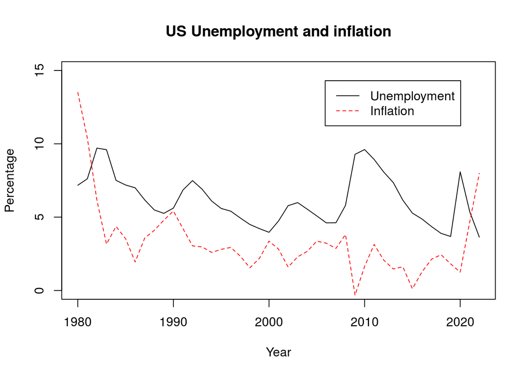

```r
plot(1980:2022, dat$Unemployment, type = 'l', ylim = c(0, 15),
     main = "US Unemployment and inflation", xlab = "Year",
     ylab = "Percentage")
lines(1980:2022, dat$Inflation, col = 'red', lty = 2)
legend('topright', inset = 0.08, legend = c("Unemployment",
              "Inflation"),  col = c('black', 'red'), lty = c(1, 2))
```

There seems to be a mirror, as we would expect for the Phillips curve. However, that is less apparent when we use a scattergram.

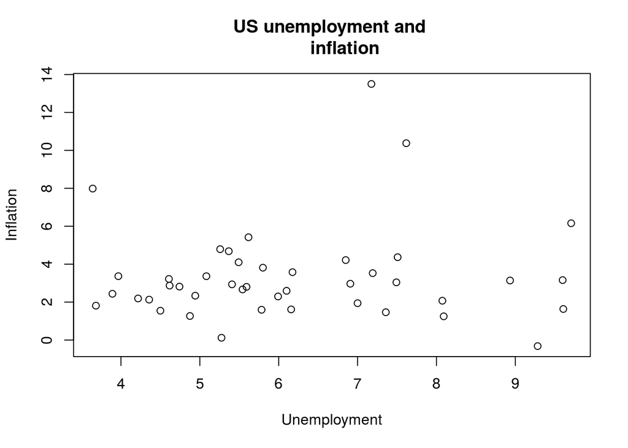

```r
plot(dat$Unemployment, dat$Inflation, main = "US unemployment and
     inflation", xlab = "Unemployment", ylab = "Inflation")
```

## Linear regression

The `lm()` is the function for a **linear regression**. We can create a regression object with the regression results.

```r
eq1 <- lm(dat$Inflation ~ dat$Unemployment)
summary(eq1)
```

```
##
## Call:
## lm(formula = dat$Inflation ~ dat$Unemployment)
##
## Residuals:
##     Min      1Q  Median      3Q     Max
## -3.9356 -1.3533 -0.4428  0.3901 10.0842
##
## Coefficients:
##                  Estimate Std. Error t value Pr(>|t|)
## (Intercept)       2.74476    1.45162   1.891   0.0657 .
## dat$Unemployment  0.09381    0.22728   0.413   0.6819
## ---
## Signif. codes:  0 '***' 0.001 '**' 0.01 '*' 0.05 '.' 0.1 ' ' 1
##
## Residual standard error: 2.489 on 41 degrees of freedom
## Multiple R-squared:  0.004138,   Adjusted R-squared:  -0.02015
## F-statistic: 0.1704 on 1 and 41 DF,  p-value: 0.6819
```

You can see the results using the `summary()` function. You can see from this that the R-squared is very low and the estimate of the slope is not statistically significant. However, if you look at the original time series chart you can see that the starting and ending points are the end of the high inflation 1970s and the beginning of the recent inflation phase. We could look at the results when these periods are removed.

```r
dat2 <- dat[9:length(dat$Unemployment) -3, ]
head(dat2)
```

```
##      Unemployment Inflation
## 1985        7.192     3.528
## 1986        7.000     1.944
## 1987        6.175     3.578
## 1988        5.492     4.100
## 1989        5.258     4.791
## 1990        5.617     5.419
```

```r
tail(dat2)
```

```
##      Unemployment Inflation
## 2014        6.158     1.615
## 2015        5.275     0.121
## 2016        4.875     1.267
## 2017        4.358     2.131
## 2018        3.892     2.439
## 2019        3.683     1.813
```

Now another regression

```r
eq2 <- lm(dat2$Inflation ~ dat2$Unemployment)
summary(eq2)
```

```
##
## Call:
## lm(formula = dat2$Inflation ~ dat2$Unemployment)
##
## Residuals:
##      Min       1Q   Median       3Q      Max
## -2.57084 -0.65736  0.01069  0.64290  2.77132
##
## Coefficients:
##                   Estimate Std. Error t value Pr(>|t|)
## (Intercept)         3.3730     0.8133   4.147 0.000221 ***
## dat2$Unemployment  -0.1291     0.1337  -0.965 0.341326
## ---
## Signif. codes:  0 '***' 0.001 '**' 0.01 '*' 0.05 '.' 0.1 ' ' 1
##
## Residual standard error: 1.177 on 33 degrees of freedom
## Multiple R-squared:  0.02747,    Adjusted R-squared:  -0.001999
## F-statistic: 0.9322 on 1 and 33 DF,  p-value: 0.3413
```

It is possible to extract elements of the regression results. To see the options use the `names()` function.

```r
names(eq1)
```

```
##  [1] "coefficients"  "residuals"     "effects"       "rank"
##  [5] "fitted.values" "assign"        "qr"            "df.residual"
##  [9] "xlevels"       "call"          "terms"         "model"
```

You can see that one of these is `residuals`. We can plot the residuals to see if they are random as should be the case if nothing important is missing from the model.

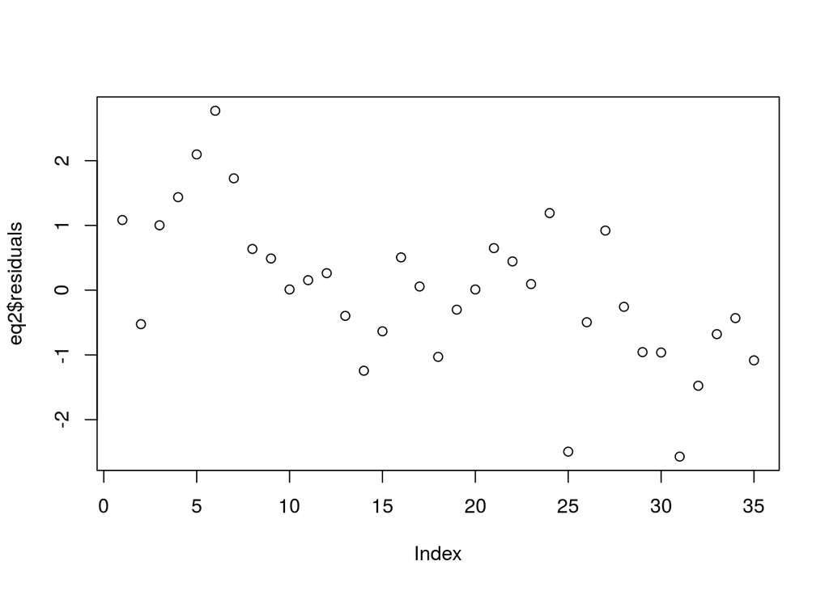

```r
plot(eq2$residuals)
```

What is notable here is the downward trend to the residuals. This can be estimated using a time trend (like we did with the GDP data in excel).

```r
eq3 <- lm(eq2$residuals ~ I(1:35))
summary(eq3)
```

```
##
## Call:
## lm(formula = eq2$residuals ~ I(1:35))
##
## Residuals:
##      Min       1Q   Median       3Q      Max
## -2.01051 -0.41931 -0.03432  0.45418  1.94196
##
## Coefficients:
##             Estimate Std. Error t value Pr(>|t|)
## (Intercept)  1.24403    0.32197   3.864 0.000494 ***
## I(1:35)     -0.06911    0.01560  -4.430 9.77e-05 ***
## ---
## Signif. codes:  0 '***' 0.001 '**' 0.01 '*' 0.05 '.' 0.1 ' ' 1
##
## Residual standard error: 0.9321 on 33 degrees of freedom
## Multiple R-squared:  0.373,  Adjusted R-squared:  0.354
## F-statistic: 19.63 on 1 and 33 DF,  p-value: 9.771e-05
```

We can add this to the residual plot.

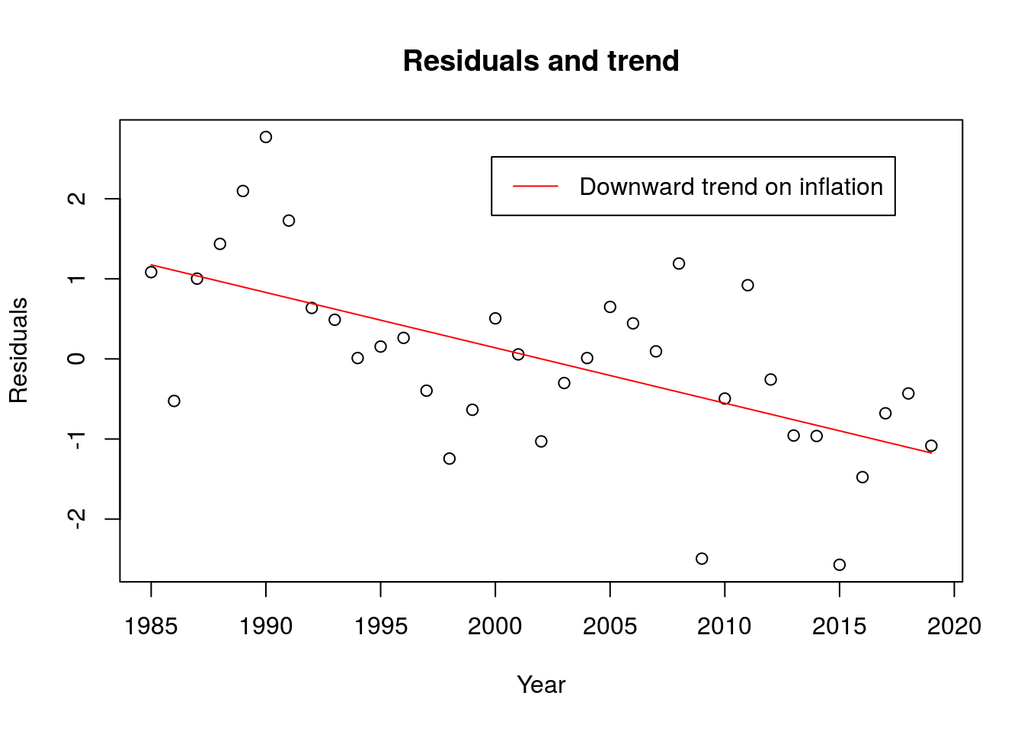

```r
plot(1985:2019, eq2$residuals, main = "Residuals and trend",
     xlab = "Year", ylab = "Residuals")
lines(1985:2019, eq3$fitted.values, col = 'red')
legend('topright', inset = 0.08, legend =
         "Downward trend on inflation", lty = 1, col = 'red')
```

There is something additional putting downward pressure on inflation (other than unemployment). We might add other variables to the model to try to account for these. For example, some suggest that the balance between labour and capital has been tipped more decisively on the side of capital and this makes is much harder for workers to take advantage of tight labour markets. This might be measured by the level of union membership or the level of industry concentration.